# Untitled

Eric Asare,Ph.D.

11/5/2020

# What I expect you to know how to perform steps (1-5) with R at the end of workshop!

[interactive chart not shown]

# General Overview of R

## History of R

- R is a programming language which was created in 1991 by Ross Ihaka and Robert Gentleman.
- It was created originally for data analysis and graphics, and documented in this puplished paper:

> Ross Ihaka and Robert Gentleman. R: A language for data analysis and graphics. Journal of Computational and Graphical Statistics, 5(3):299–314, 1996  
> http://biostat.mc.vanderbilt.edu/wiki/pub/Main/JeffreyHorner/JCGSR.pdf
- Martin Mächler in 1995 convinced the creators of R to use the GNU General Public License to make R free software.
- In 2000 R version 1.0.0 was released to the public.
- R has remained an open source software till today with a great online community of users and support.

For more details on the history of R see https://www.r-project.org/about.html.

## How Popular is R as a Programming Language?

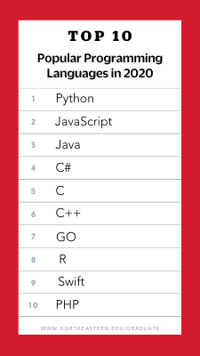

Popular Programming Languages in the World

Source: https://www.northeastern.edu/graduate/blog/most-popular-programming-languages/

# R Studio

- It is an integrated development environment for R, a programming language for statistical computing and graphics.

### Project Management

- We wil thtough an example of how to properly manage your research project to make your life easy!

## Basic R To Know!

### Data types

It is an attribute of data which tells the compiler or interpreter how the programmer intends to use the data. The primitive data types are:

- character: “a”, “swc”
- numeric: 2, 15.5
- integer: 2L (the L tells R to store this as an integer)
- blogical: TRUE, FALSE
- complex: 1+4i (complex numbers with real and imaginary parts

Functions to check to examnine attributes of data types

- class() - what kind of object is it (high-level)?
- typeof() - what is the object’s data type (low-level)?
- length() - how long is it? What about two dimensional objects?
- attributes() - does it have any metadata?

```r
x <- "Eric"
class(x)
```

```
## [1] "character"
```

### Function

Provides a means to work on a data object: Select, transform, filter and many more

```r
addnumbers <- function(x, y){
  sum <- x +y
  return(sum)
}

addnumbers(2,5)
```

```
## [1] 7
```

### Control Mechanism

```r
if (1 >3){
  print("yes")
}else {
  print("No")
}
```

```
## [1] "No"
```

### Installing Packages

- A package bundles together code, data, documentation, and tests, and is easy to share with others
- We are going to work with the tidyverse package for data analysis.
- We use the install.packages(“package”) to install and library(“package”) to activate it.

```r
#install.packages("tidyverse")
library("tidyverse")
```

## Tidyverse

The tidyverse is an opinionated collection of R packages designed for data science.

Let’s check its website: < https://www.tidyverse.org/>

### Packages within tidyverse

- ggplot2 : is a system for declaratively creating graphics
- dplyr : provides a grammar of data manipulation, providing a consistent set of verbs that solve the most common data manipulation challenges
- readr : provides a fast and friendly way to read rectangular data
- tidymodels : provide a comprehensive foundation for creating and using models of all types
- purr and many others…

### Reading in Data

### Data Cleaning or Wrangling

#### PURR

### Data Exploration/Visualization

#### GGLOT

### Data Analysis

### Recap

## Conclusion

## Further Training